# crabs

Jay Lee

2020 9 30

고급R활용 5장 연습문제 4번 crab 데이터 분석

**변수**

[output not shown]

**데이터 설명**

```
## [1] 200   8
```

crabs 데이터의 자료는 200개이며 변수는 8개이다.

crabs 몸통 크기 측정 결과 변수의 요약 통계량은 아래와 같다.

```
##        FL              RW              CL              CW
##  Min.   : 7.20   Min.   : 6.50   Min.   :14.70   Min.   :17.10
##  1st Qu.:12.90   1st Qu.:11.00   1st Qu.:27.27   1st Qu.:31.50
##  Median :15.55   Median :12.80   Median :32.10   Median :36.80
##  Mean   :15.58   Mean   :12.74   Mean   :32.11   Mean   :36.41
##  3rd Qu.:18.05   3rd Qu.:14.30   3rd Qu.:37.23   3rd Qu.:42.00
##  Max.   :23.10   Max.   :20.20   Max.   :47.60   Max.   :54.60
##        BD
##  Min.   : 6.10
##  1st Qu.:11.40
##  Median :13.90
##  Mean   :14.03
##  3rd Qu.:16.60
##  Max.   :21.60
```

**몸통 크기 측정 변수 개요**

히스토그램과 Q-Q plot으로 몸통 측정변수인 FL, RW, CL, CW, BD의 분포를 확인한 결과, 모든 변수가 정규분포를 따르고 있는 것을 확인할 수 있었다. 따라서 crab의 종류 및 성에 따른 데이터 간 차이에 대하여 정규성을 가정한 다양한 통계 검정이 가능하다.

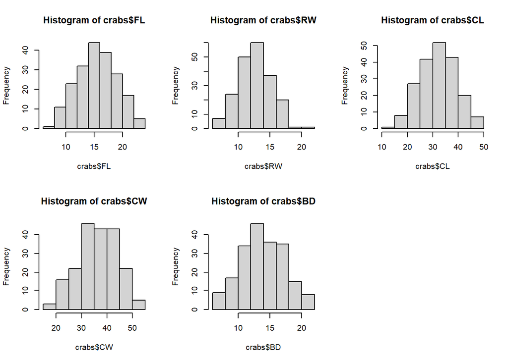

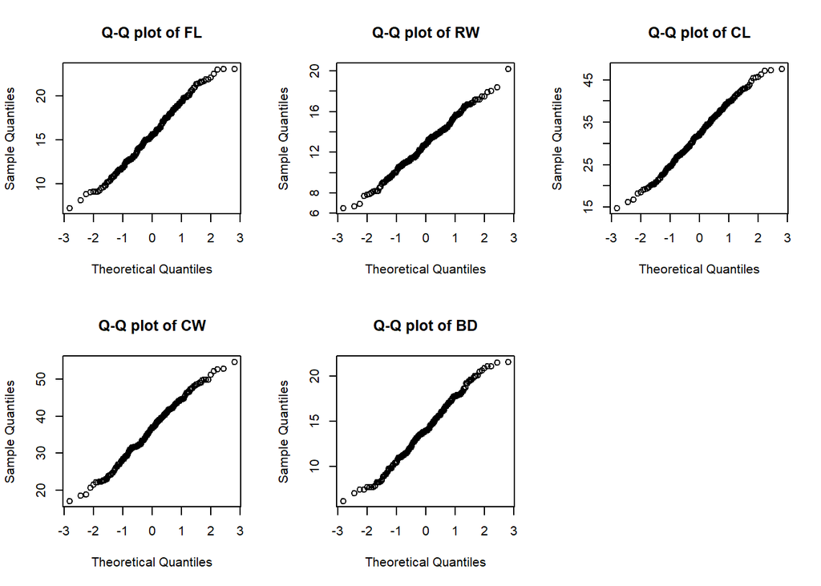

각 변수의 상자그림을 통해 RW 변수에서 1.5IQR 범위를 벗어나는 이상치가 있음을 확인하였다. RW 변수의 분석 시 해당 결측치를 제거하고 분석을 시행할 계획이다.

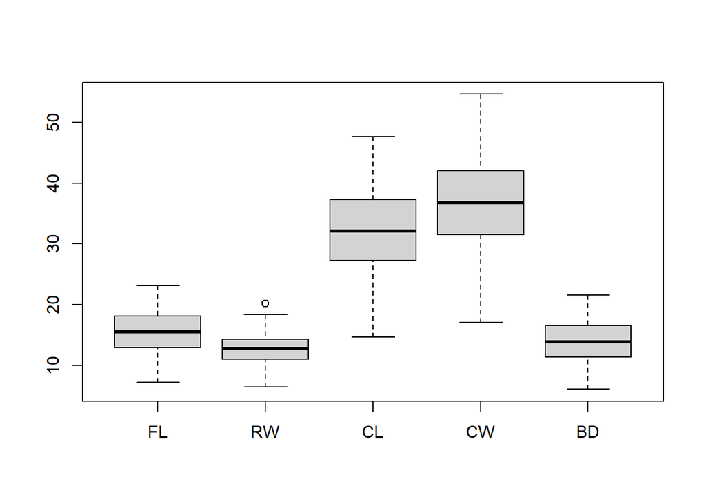

**종류 및 성별에 따른 FL 분석**

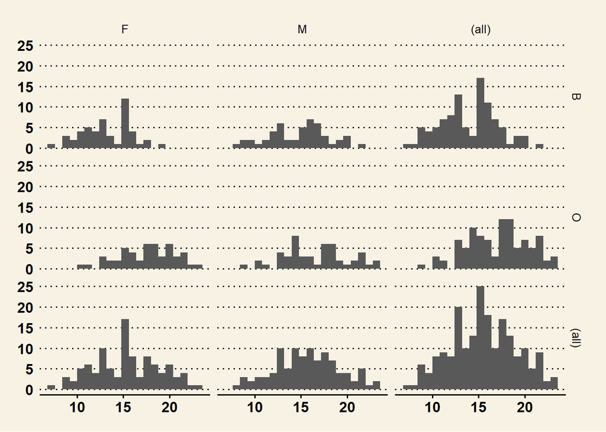

개체 종류와 성별 두 변수의 interaction effect plot을 확인한 결과 개체 종류와 성별에 따른 교호작용이 있는 것으로 판단된다.

```
##   sp FL.mean    FL.sd FL.min FL.max
## 1  B  14.056 3.019610    7.2   21.3
## 2  O  17.110 3.275575    9.1   23.1
```

```
##   sex FL.mean    FL.sd FL.min FL.max
## 1   F  15.432 3.537930    7.2   23.1
## 2   M  15.734 3.463379    8.1   23.1
```

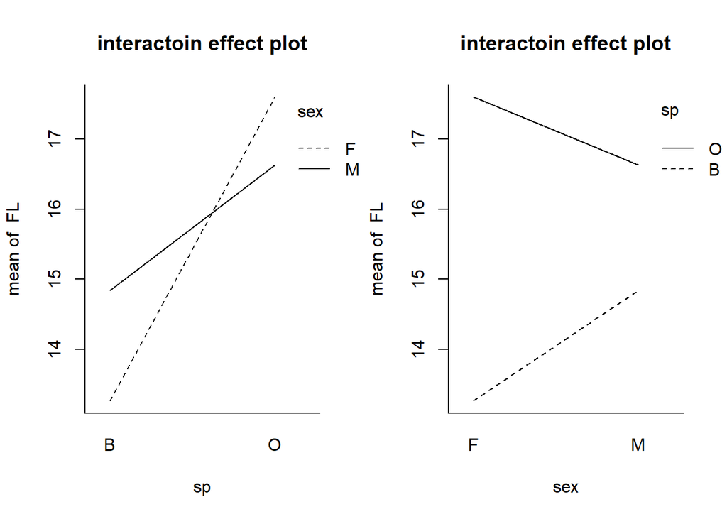

보다 정확한 분석을 위해 FL에 대한 두 변수의 이원배치 분산분석을 시행한 결과 개체 종류에 따른 FL의 차이의 유의확률은 유의수준보다 0.001보다 작아 통계적으로 유의미히다. 개체 종류와 성별의 교호작용의 유의확률은 유의수준 0.01보다 작아 FL의 차이가 없다는 귀무가설을 기각할 수 있다. 반면, 암컷과 수컷의 FL 차이의 유의확률이 0.1보다 커 유의수준 0.1, 0.05, 0.001 등의 수준에서 통계적으로 유의미하지 않은 것으로 나타났다.

```
##              Df Sum Sq Mean Sq F value   Pr(>F)
## sp            1  466.3   466.3  48.627 4.63e-11 ***
## sex           1    4.6     4.6   0.476  0.49128
## sp:sex        1   80.6    80.6   8.409  0.00416 **
## Residuals   196 1879.7     9.6
## ---
## Signif. codes:  0 '***' 0.001 '**' 0.01 '*' 0.05 '.' 0.1 ' ' 1
```

**종류 및 성별에 따른 RW 분석**

RW에 대한 분석 전 결측치 처리를 수행하였다.

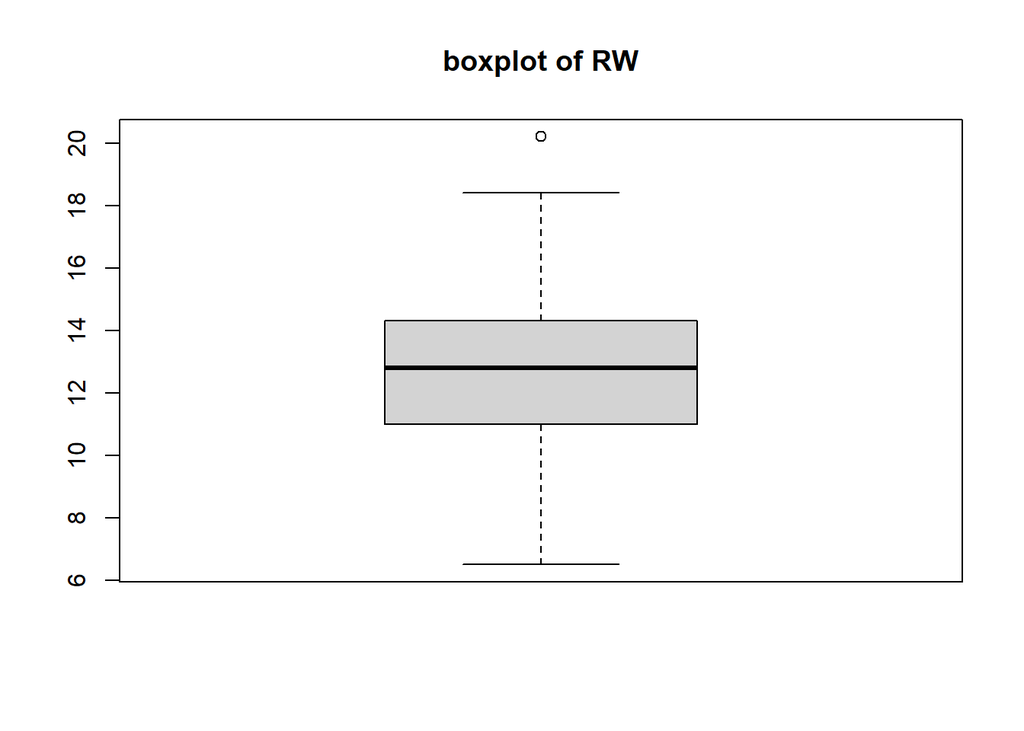

```
##      [,1]
## [1,]  6.5
## [2,] 11.0
## [3,] 12.8
## [4,] 14.3
## [5,] 18.4
```

결측치 처리 전 결측치 갯수는 0이었으나

```
## [1] 0
```

처리 후 1개임을 확인하였다.

```
## [1] 1
```

결측치를 제외하고 개체의 종류와 성별에 따른 RW의 분포 차이를 확인하기 위해 히스토그램을 분석한 결과 암컷이 수컷 대비 오른쪽으로 치우친 넓고 완만한 분포를 보이는 것을 확인할 수 있었다. 개체의 종류에 따르면 “O” 개체가 “B” 가체보다 우측으로 치우친 완만한 분포를 보이는 경향이 있다. 즉 암컷이 수컷보다 평균과 분산이 모두 크고 “O”개체가 “B”개체보다 평균과 분산이 모두 큰 분포를 보인다. 개체 종류와 성별을 교차 분석한 결과 암컷은 “O” 개체가 “B” 개체보다 우측으로 치우친 분포를 보이는 반면, 수컷은 개체 차이에 따른 분포의 차이가 뚜렷하지 않다. 즉, 암컷의 경우 개체 종류에 따라 RW의 차이가 나타나는 반면 수컷은 개체 종류에 따른 RW의 차이가 나타나지 않는 것으로 보인다. 반면 “B” 개체는 암컷과 수컷의 분포 모양이 비슷한 것으로 보이나 “O” 개체의 경우 암컷은 수컷대비 우측으로 치우친 분포를 보이고 있다.

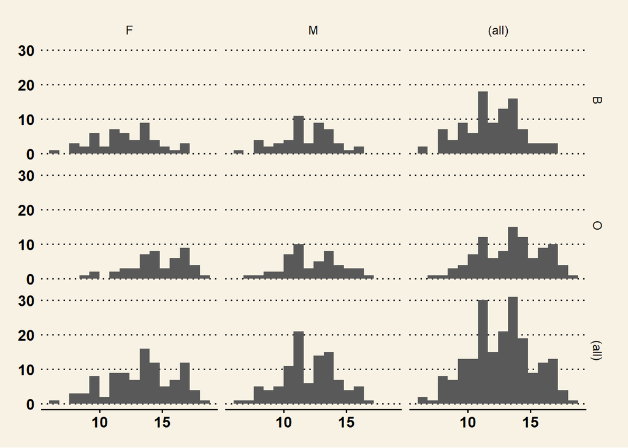

```
##   sp  RW.mean    RW.sd RW.min RW.max
## 1  B 11.92800 2.279291    6.5   16.9
## 2  O 13.48182 2.530240    6.9   18.4
```

```
##   sex  RW.mean    RW.sd RW.min RW.max
## 1   F 13.41919 2.669009    6.5   18.4
## 2   M 11.99000 2.160504    6.7   16.8
```

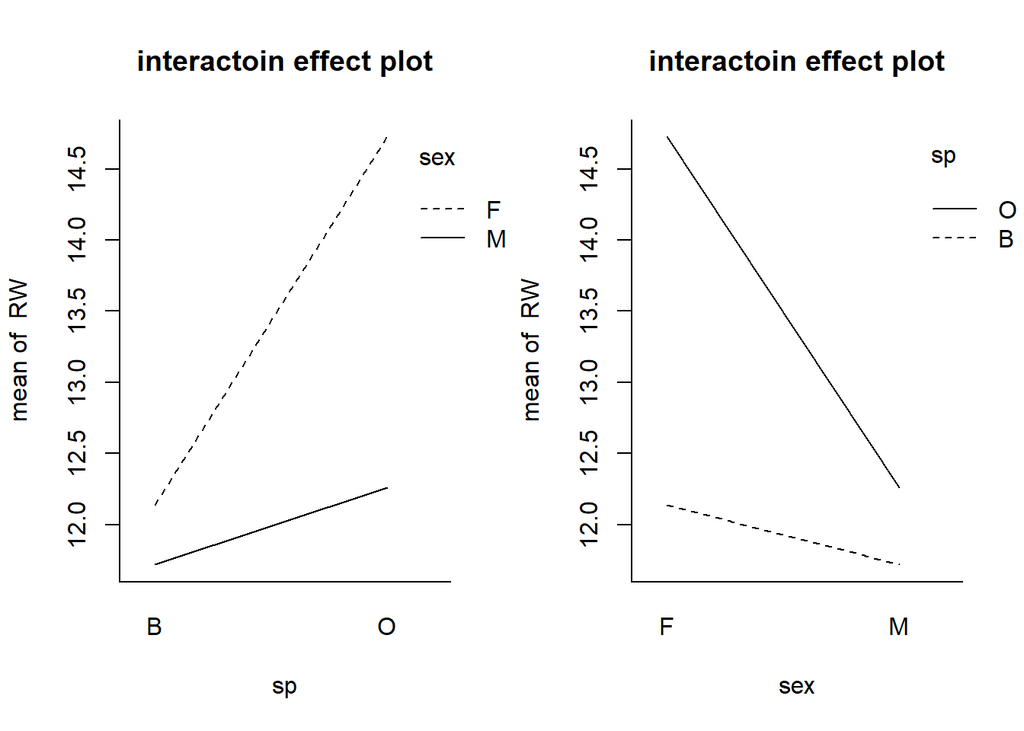

보다 정확한 분석을 위해 RW에 대한 두 변수의 이원배치 분산분석을 시행한 결과 종류와 성별에 따른 차이는 유의수준 0.001보다 작아 차이가 없다는 귀무가설을 기각할 수 있다. 또한 두 변수의 교호작용도 유의수준 0.01보다 작아 차이가 없다는 귀무가설을 기각할 수 있다. 즉 RW는 개체 종류와 성별, 두 변수의 교호작용에 따른 유의미한 차이가 있다고 할 수 있다.

```
##              Df Sum Sq Mean Sq F value   Pr(>F)
## sp            1  120.1  120.11   23.73 2.29e-06 ***
## sex           1  102.7  102.74   20.30 1.14e-05 ***
## sp:sex        1   52.0   51.99   10.27  0.00158 **
## Residuals   195  987.0    5.06
## ---
## Signif. codes:  0 '***' 0.001 '**' 0.01 '*' 0.05 '.' 0.1 ' ' 1
```

**종류 및 성별에 따른 CL 분석**

개체의 종류와 성별에 따른 CL의 히스토그램을 확인한 결과, 수컷이 암컷보다 다소 완만한 분포를 보인다. 개체별로 살펴보면 ’O’개체가 ’B’개체 대비 평균이 크고 완만한 분포를 보이고 있다. 암컷의 경우 ’O’개체의 평균이 크고 더 완만한 분포를 보이는 반면 수컷은 개체에 따른 분포의 차이가 크지 않은 것으로 보인다. ’B’개체의 경우 수컷이 암컷 대비 완만한 분포를 보이며 ’O’개체의 경우 수컷이 암컷 대비 범위가 넓고 더 넓게 퍼진 분포를 보인다.

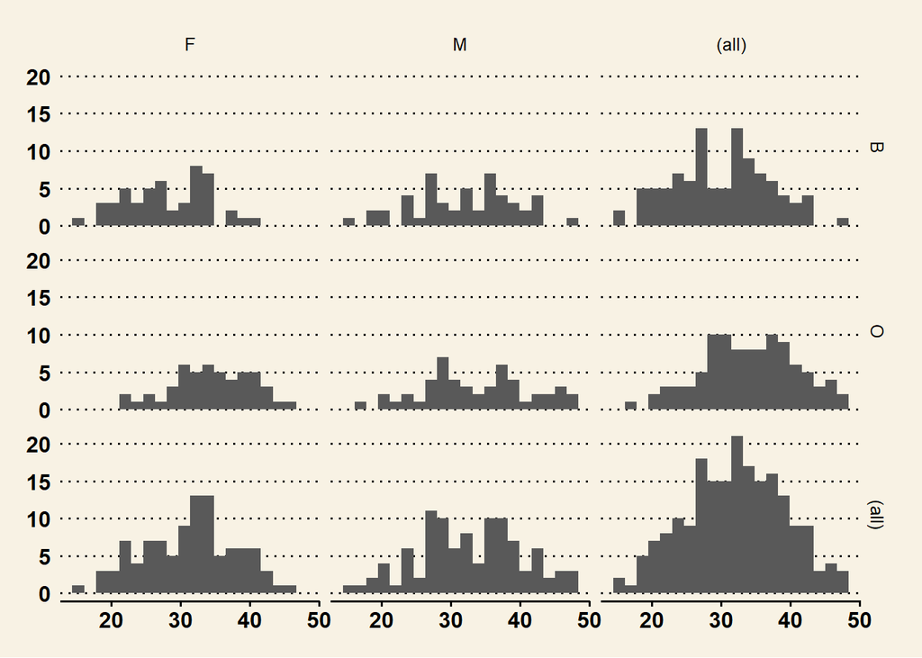

개체 종류와 성별 두 변수의 interaction effect plot을 확인한 결과 두 변수 사이에 교호작용이 있는 것으로 판단된다.

```
##   sp CL.mean    CL.sd CL.min CL.max
## 1  B  30.058 6.902703   14.7   47.1
## 2  O  34.153 6.764262   16.7   47.6
```

```
##   sex CL.mean    CL.sd CL.min CL.max
## 1   F  31.360 6.702992   14.7   46.2
## 2   M  32.851 7.471204   16.1   47.6
```

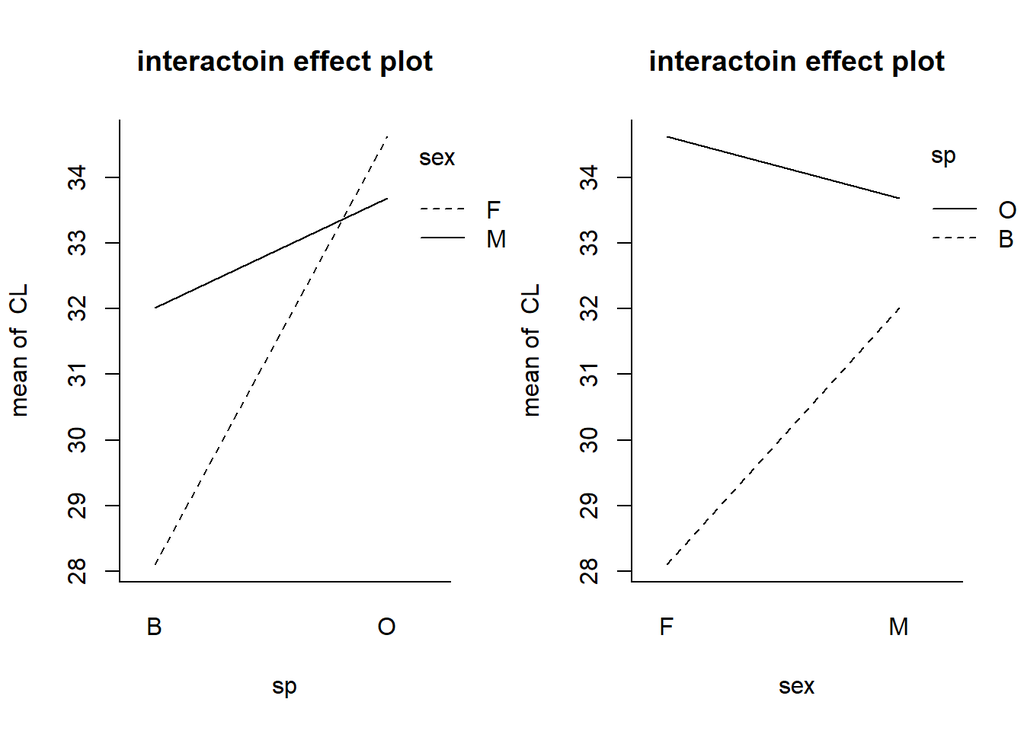

```
##              Df Sum Sq Mean Sq F value   Pr(>F)
## sp            1    838   838.5  18.585 2.57e-05 ***
## sex           1    111   111.2   2.464   0.1181
## sp:sex        1    293   293.1   6.496   0.0116 *
## Residuals   196   8843    45.1
## ---
## Signif. codes:  0 '***' 0.001 '**' 0.01 '*' 0.05 '.' 0.1 ' ' 1
```

**종류 및 성별에 따른 CW 분석**

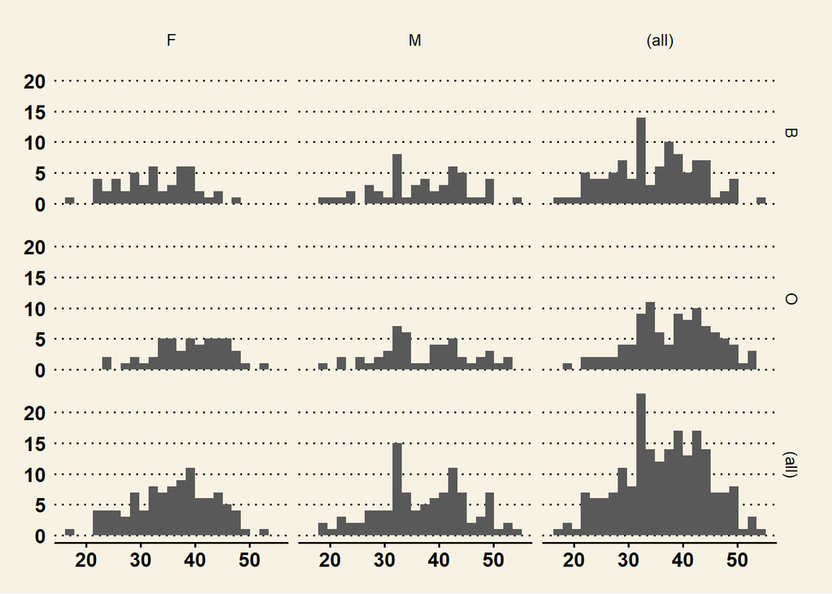

개체 종류와 성별 두 변수의 interaction effect plot을 확인한 결과 두 변수 사이에 교호작용이 있는 것으로 판단된다.

```
##   sp CW.mean    CW.sd CW.min CW.max
## 1  B  34.717 7.866038   17.1   54.6
## 2  O  38.112 7.540922   18.6   52.8
```

```
##   sex CW.mean    CW.sd CW.min CW.max
## 1   F  35.830 7.380927   17.1   52.5
## 2   M  36.999 8.330248   18.6   54.6
```

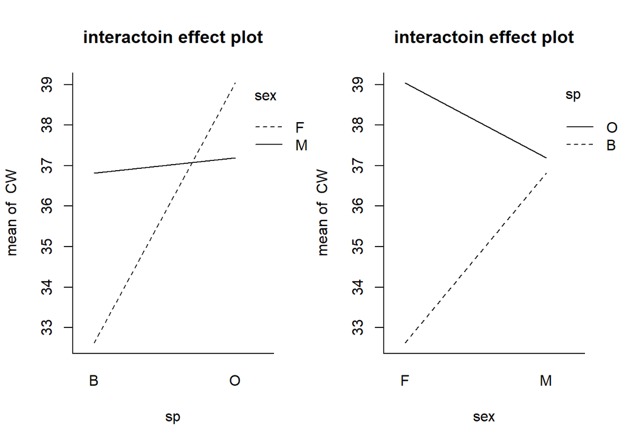

```
##              Df Sum Sq Mean Sq F value  Pr(>F)
## sp            1    576   576.3  10.057 0.00176 **
## sex           1     68    68.3   1.192 0.27620
## sp:sex        1    455   455.1   7.942 0.00533 **
## Residuals   196  11232    57.3
## ---
## Signif. codes:  0 '***' 0.001 '**' 0.01 '*' 0.05 '.' 0.1 ' ' 1
```

**종류 및 성별에 따른 BD 분석**

개체의 종류와 성별에 따른 BD의 히스토그램을 확인한 결과, 수컷이 암컷에 비해 조금 완만한 분포를 보인다. 개체별로 보면 ’B’개체 대비 ’O’개체가 평균이 크고 우측으로 치우친 분포를 보인다. 암컷의 경우 ’O’개체의 평균이 ’B’개체 대비 크고 완만한 분포를 보이는 반면 수컷은 개체의 종류에 따른 차이가 보이지 않는다. 개체 종류별로 살펴보면 ’B’개체는 암컷의 분포가 수컷 대비 완만한 모양이며 ’O’개체는 암컷은 완만한 종모양을, 수컷은 왼쪽으로 치우친 분포를 보인다.

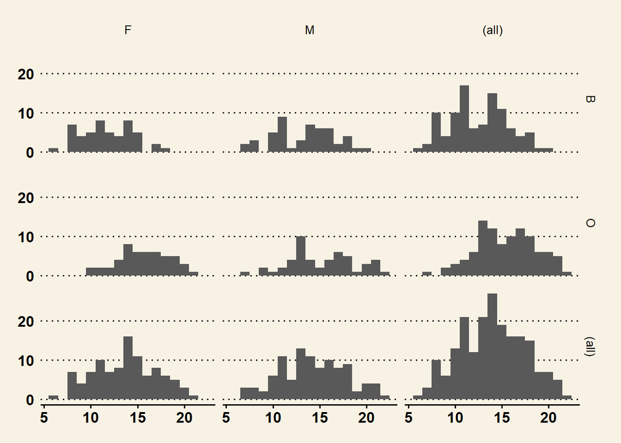

개체 종류와 성별 두 변수의 interaction effect plot을 확인한 결과 두 변수 사이에 교호작용이 있는 것으로 판단된다.

```
##   sp BD.mean    BD.sd BD.min BD.max
## 1  B  12.583 3.067887    6.1   20.0
## 2  O  15.478 3.151481    7.4   21.6
```

```
##   sex BD.mean    BD.sd BD.min BD.max
## 1   F  13.724 3.343231    6.1   21.1
## 2   M  14.337 3.494228    7.0   21.6
```

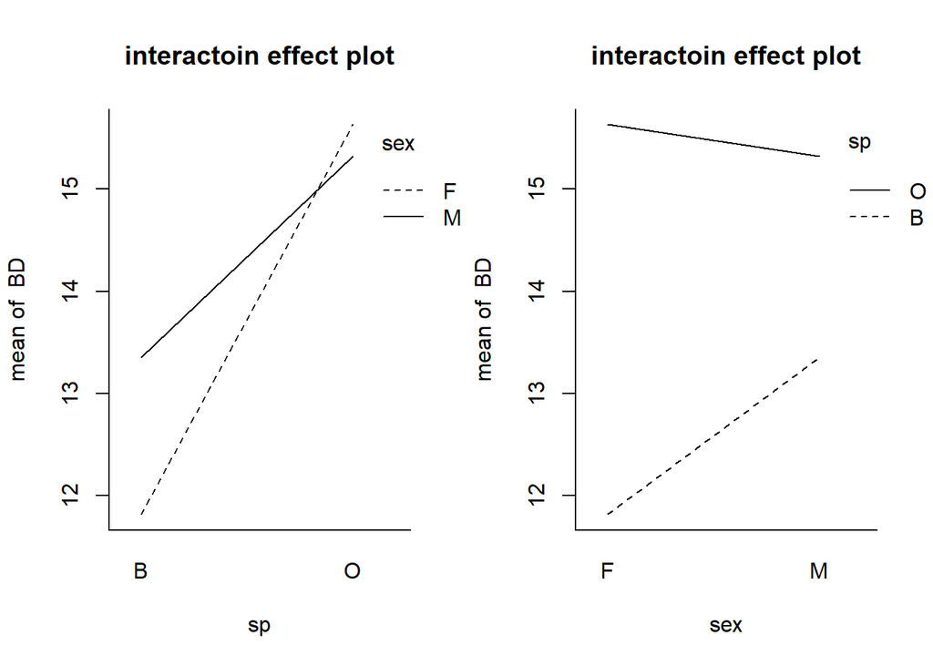

보다 정확한 분석을 위해 BD에 대한 두 변수의 이원배치 분산분석을 시행한 결과 종류에 따른 BD 차이의 유의확률은 유의수준 0.001보다 작아 통계적으로 유의미한 차이를 보인다. 두 변수의 교호작용 역시 유의수준 0.05에서 교호작용이 없다는 귀무가설을 기각하고 통계적으로 유의미한 차이가 있다고 할 수 있다. 반면 성별에 따른 BD의 차이는 유의확률이 0.1보다 커 유의수준 0.1, 0.05, 0.001 등 수준에서 통계적으로 유의미한 수준이 아닌 것으로 나타났다.

```
##              Df Sum Sq Mean Sq F value   Pr(>F)
## sp            1  419.1   419.1  44.305 2.75e-10 ***
## sex           1   18.8    18.8   1.986   0.1603
## sp:sex        1   42.4    42.4   4.484   0.0355 *
## Residuals   196 1853.8     9.5
## ---
## Signif. codes:  0 '***' 0.001 '**' 0.01 '*' 0.05 '.' 0.1 ' ' 1
```